# Exercises-1: ggplot2

Nathan Green, Imperial College London

07/09/2019

In this practical we are going to explore the functionality available in `ggplot2`.

First read in the data.

```r
library(dataPakistan)
library(ggplot2)
library(dplyr)
file_location <- system.file("extdata", package = "dataPakistan")
Admin <- readxl::read_excel(path = paste0(file_location, "/Admin-datasheet-year2018.xlsx"))
AFP <- readxl::read_excel(path = paste0(file_location, "/List of AFP Cases 2015-2019.xlsx"),
                          sheet = "Data")
pop <- readxl::read_excel(path =
              paste0(file_location, "/Population under 15-estimates 2018-19 as 190510.xlsx"))
```

### Scatter plot

Create a scatter plot with defined x-axis limits.

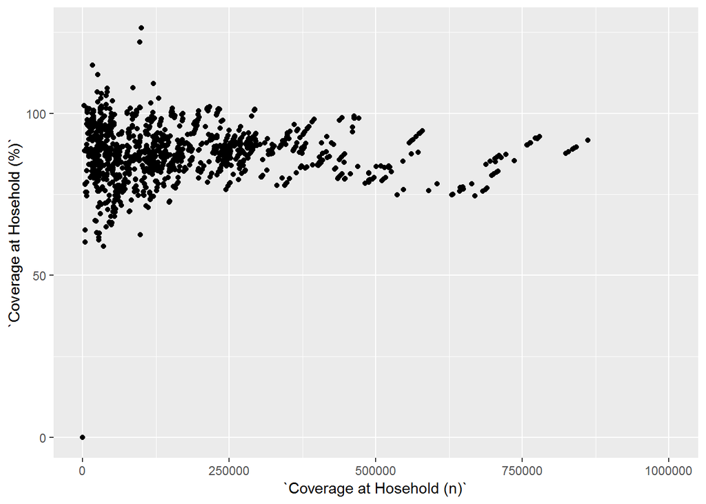

```r
ggplot(data = Admin, mapping = aes(x = `Coverage at Hosehold (n)`,
                                 y = `Coverage at Hosehold (%)`)) + geom_point() + xlim(0, 1e+6)
```

We can assign the plot to a variable in the same way as any other value. This means we can then add to and plot it again later.

```r
my_plot <- ggplot(data = Admin, mapping = aes(x = `Coverage at Hosehold (n)`,
                                            y = `Coverage at Hosehold (%)`))
```

For example, if we wanted to zoom in on a part of the plot.

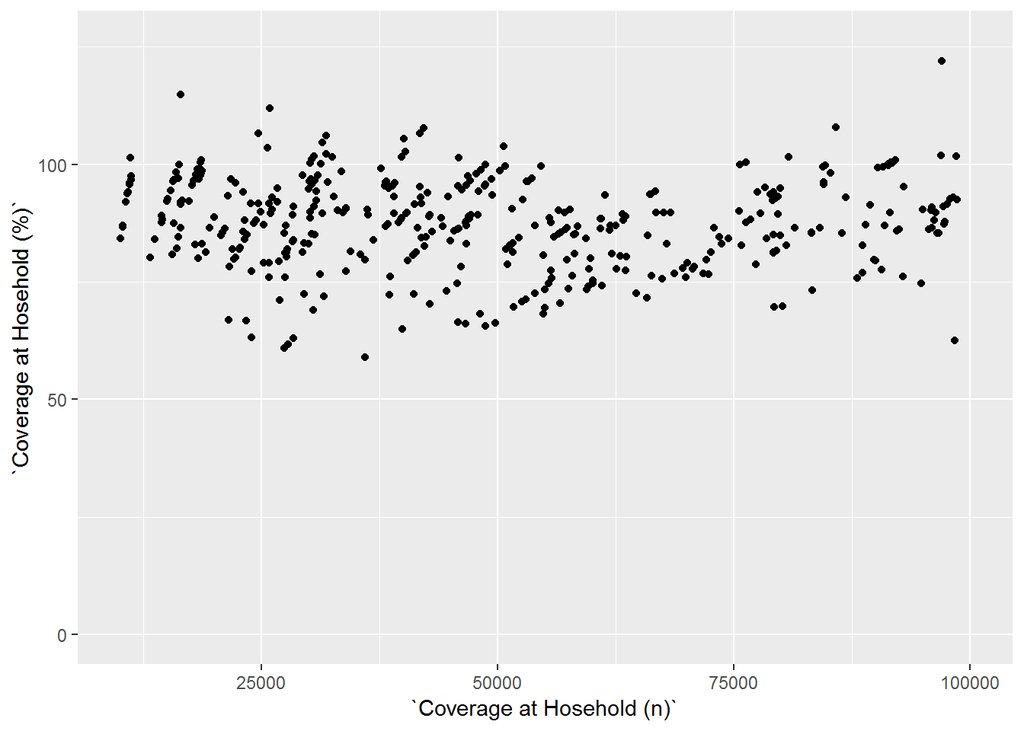

```r
my_plot + geom_point() + xlim(1e+4, 1e+5)
```

### Time series

Lets use the AFP cases data. First, aggregate the data by year of onset month and district. This gives the total number of cases for each.

```r
AFP_agg <-
  AFP %>%
  group_by(YRONSET, MTHONSET, DISTRICT) %>%
  summarise(cases = n())
```

Now create a new column of combined month and year of onset so that we can order the points in time.

```r
AFP_agg$yearmonth <- paste(AFP_agg$YRONSET, AFP_agg$MTHONSET, sep = "_")
```

So that we can clearly see the data, lets look at a single District e.g. Attock.

```r
AFP_ATTOCK <- AFP_agg[AFP_agg$DISTRICT == "ATTOCK", ]
```

Now we are ready to plot. Plot number of cases by time as a scatter plot.

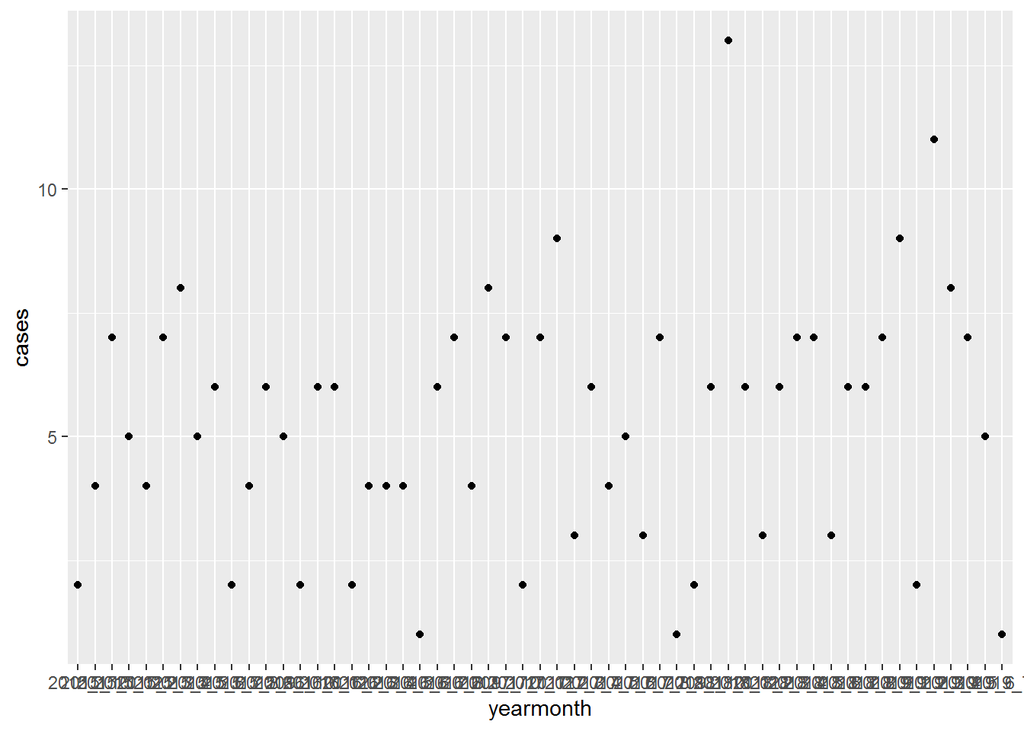

```r
ggplot(AFP_ATTOCK, aes(x=yearmonth, y=cases)) + geom_point()
```

For exposition lets looks at a single year e.g. 2018. Subset the data set to just this year.

```r
AFP_ATTOCK2018 <- AFP_ATTOCK[AFP_ATTOCK$YRONSET == 2018, ]
```

Now plot the scatter plot again.

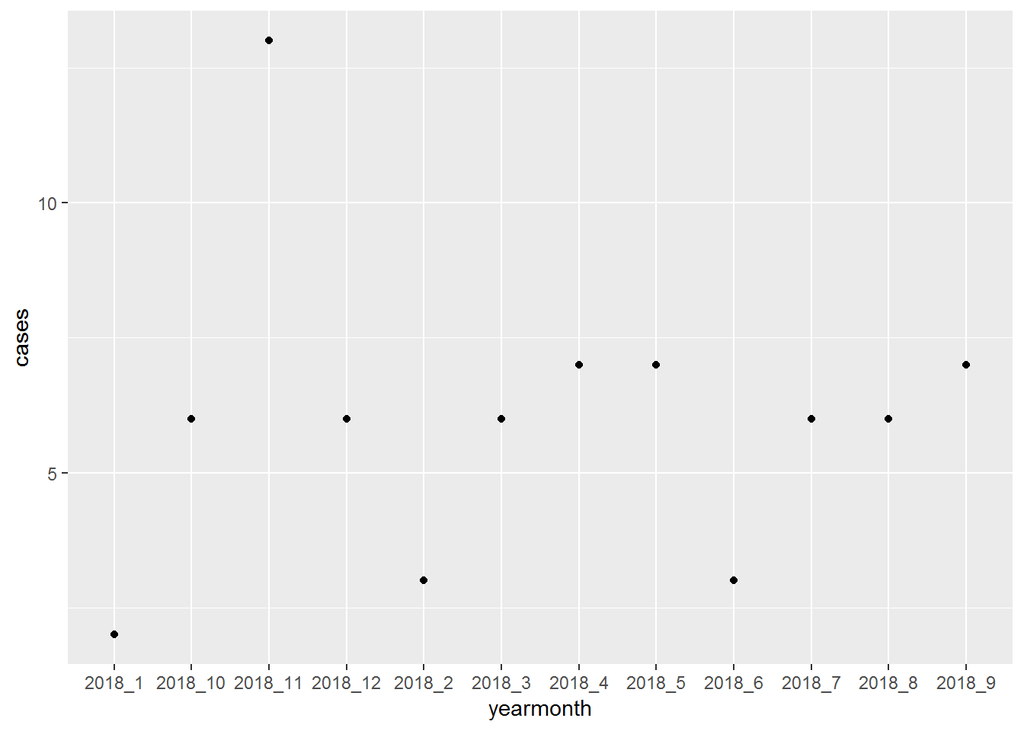

```r
ggplot(AFP_ATTOCK2018, aes(x=yearmonth, y=cases)) + geom_point()
```

Notice that the months are not in the correct sequence. This is another case of ordering the levels of factors. Lets create a vector of what order we want them to have.

```r
LEVELS <-
  c(paste("2015", 1:12, sep = "_"),
    paste("2016", 1:12, sep = "_"),
    paste("2017", 1:12, sep = "_"),
    paste("2018", 1:12, sep = "_"),
    paste("2019", 1:12, sep = "_"))
```

And then make this the order in the data.

```r
AFP_ATTOCK2018$yearmonthFACTOR <- factor(AFP_ATTOCK2018$yearmonth, levels = LEVELS)
```

Finally, plot again to check.

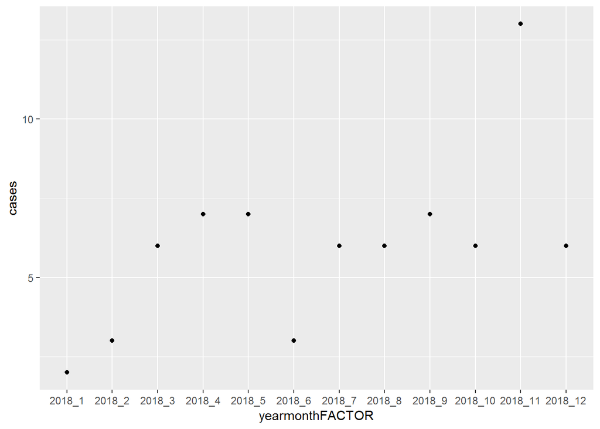

```r
ggplot(AFP_ATTOCK2018, aes(x=yearmonthFACTOR, y=cases)) + geom_point()
```

### Adding a line

Use the `geom_line()` function.

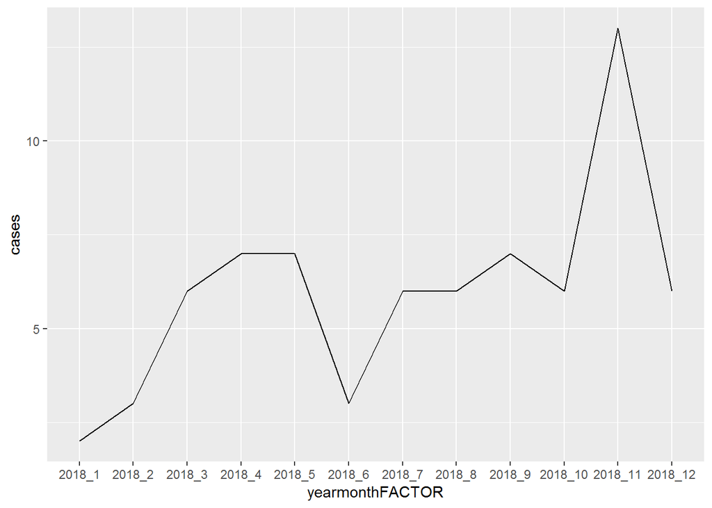

```r
my_plot <-
  ggplot(AFP_ATTOCK2018, aes(x=yearmonthFACTOR, y=cases, group=1)) + geom_line()

my_plot
```

### Adding titles and labelling

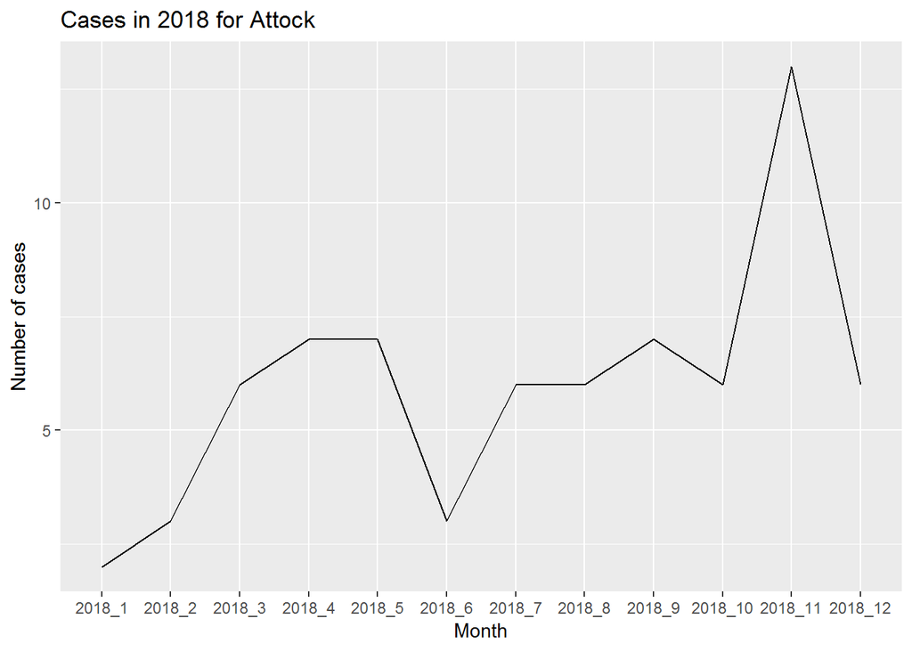

```r
my_plot + ggtitle("Cases in 2018 for Attock") +
  xlab("Month") + ylab("Number of cases")
```

### Changing plot type

Creating a histogram uses the `geom_histogram`.

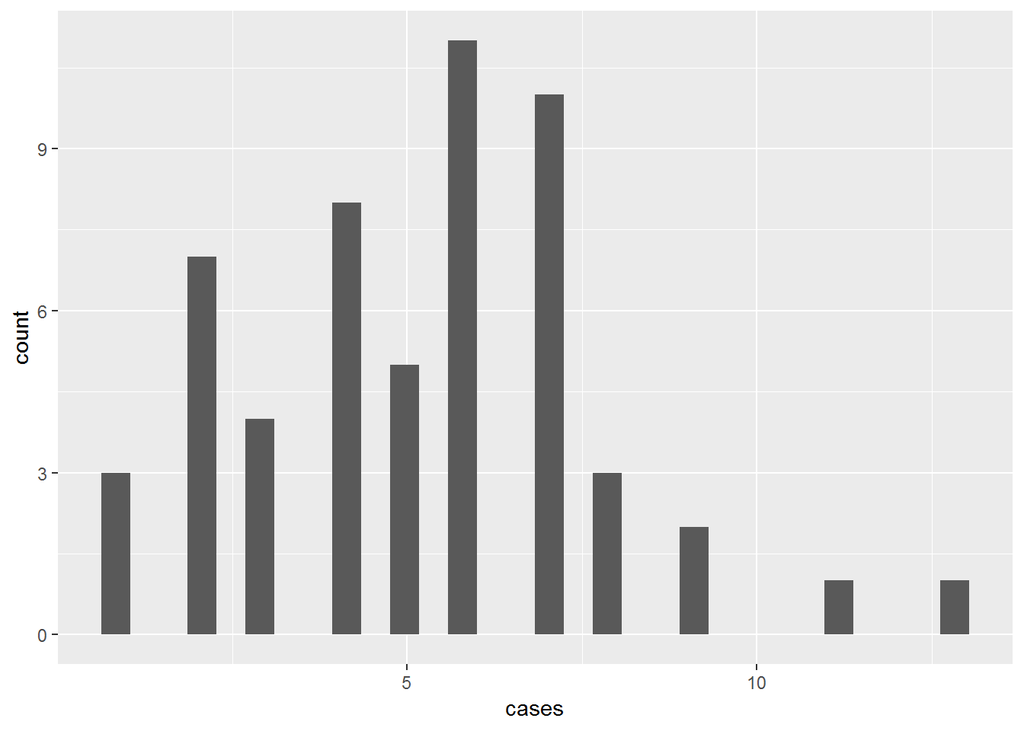

```r
plot_hist <-
  ggplot(AFP_ATTOCK, aes(x=cases)) + geom_histogram()

plot_hist
```

Show more tick marks on the x-axis.

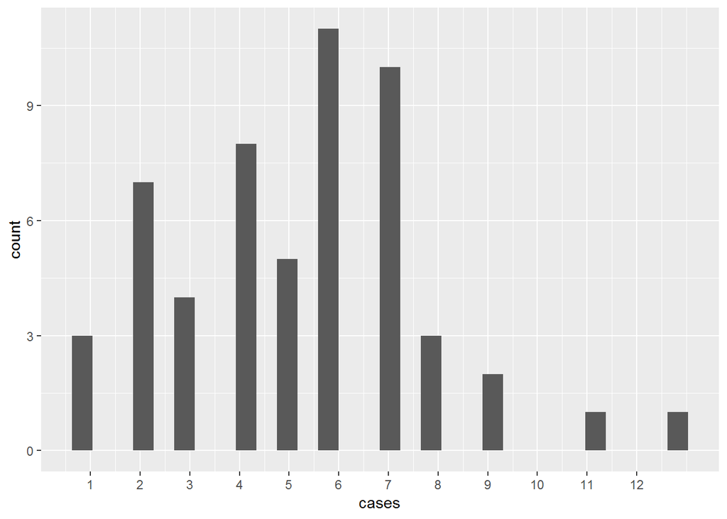

```r
plot_hist + scale_x_continuous(breaks = seq(1,12))
```

We can change the colours of the outlines, bar fill in the same way as for base R.

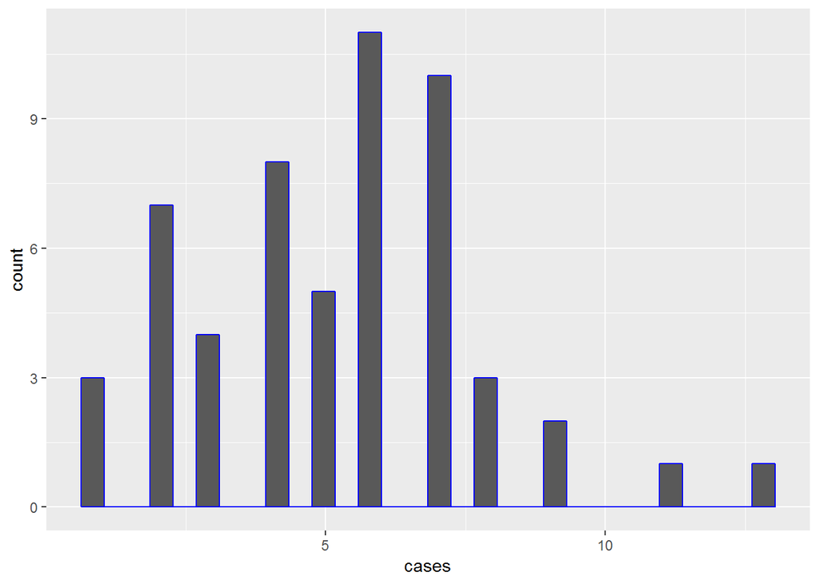

```r
 ggplot(AFP_ATTOCK, aes(x=cases)) + geom_histogram(colour = "blue")
```

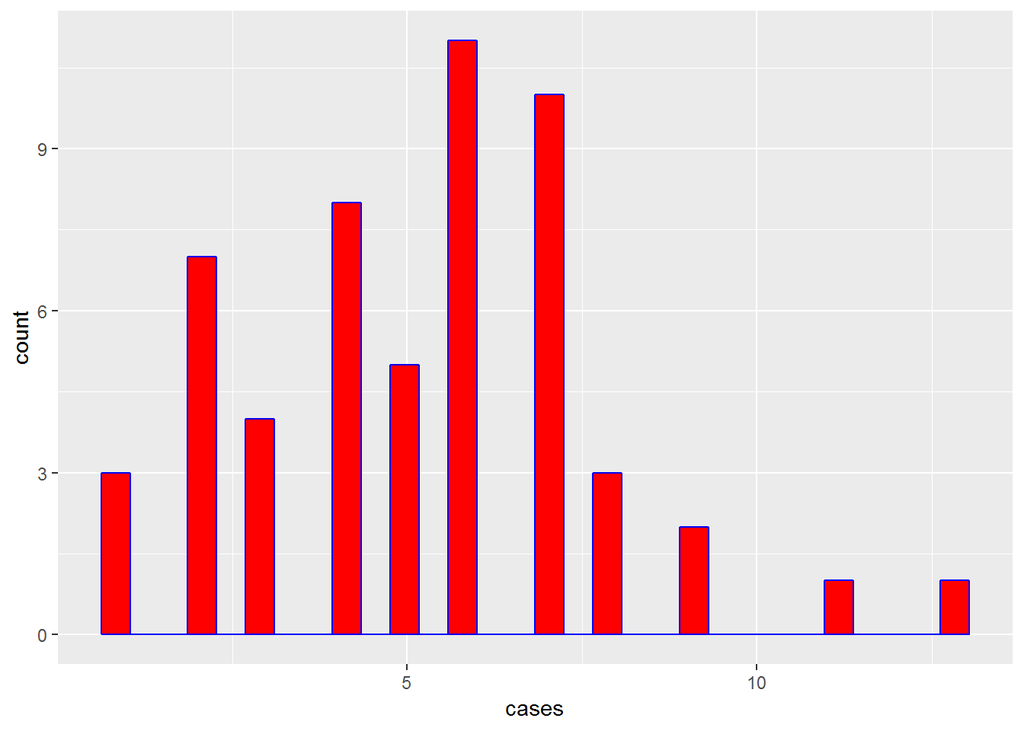

```r
 ggplot(AFP_ATTOCK, aes(x=cases)) + geom_histogram(colour = "blue", fill = "red")
```

We can also change the bin sizes that the histogram uses.

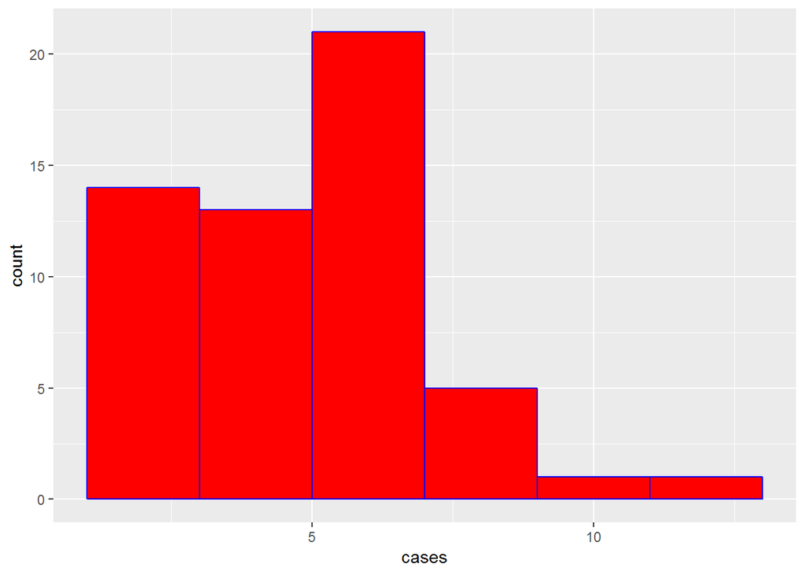

```r
ggplot(AFP_ATTOCK, aes(x=cases)) + geom_histogram(colour = "blue", fill = "red", binwidth = 2)
```

### Change point style

Change the point to triangles.

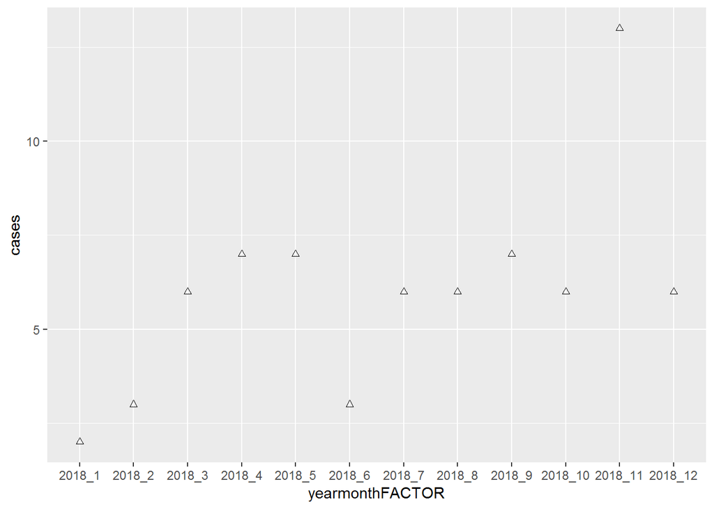

```r
ggplot(AFP_ATTOCK2018, aes(x=yearmonthFACTOR, y=cases, group=1)) + geom_point(shape = 2)
```

Chnge the sizes of the points.

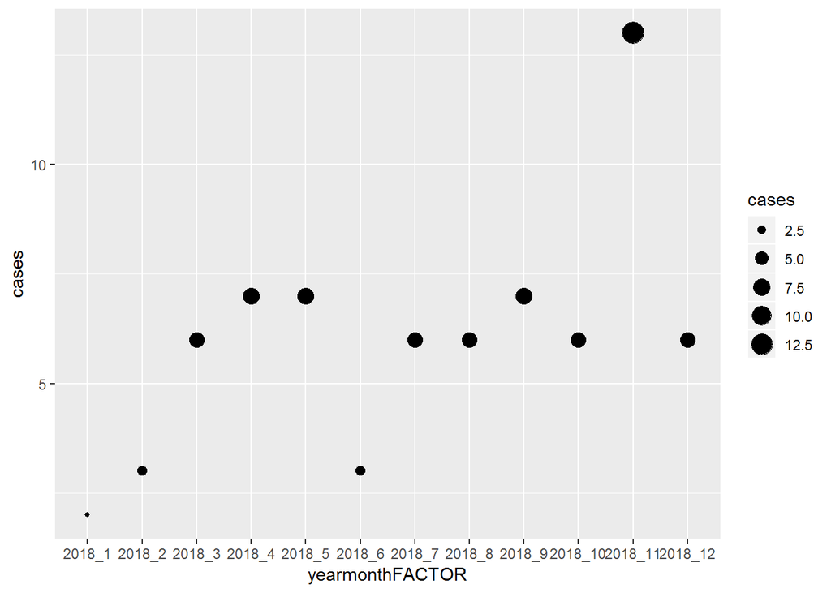

```r
ggplot(AFP_ATTOCK2018, aes(x=yearmonthFACTOR, y=cases, group=1)) + geom_point(aes(size = cases))
```

### Rotate axis labels

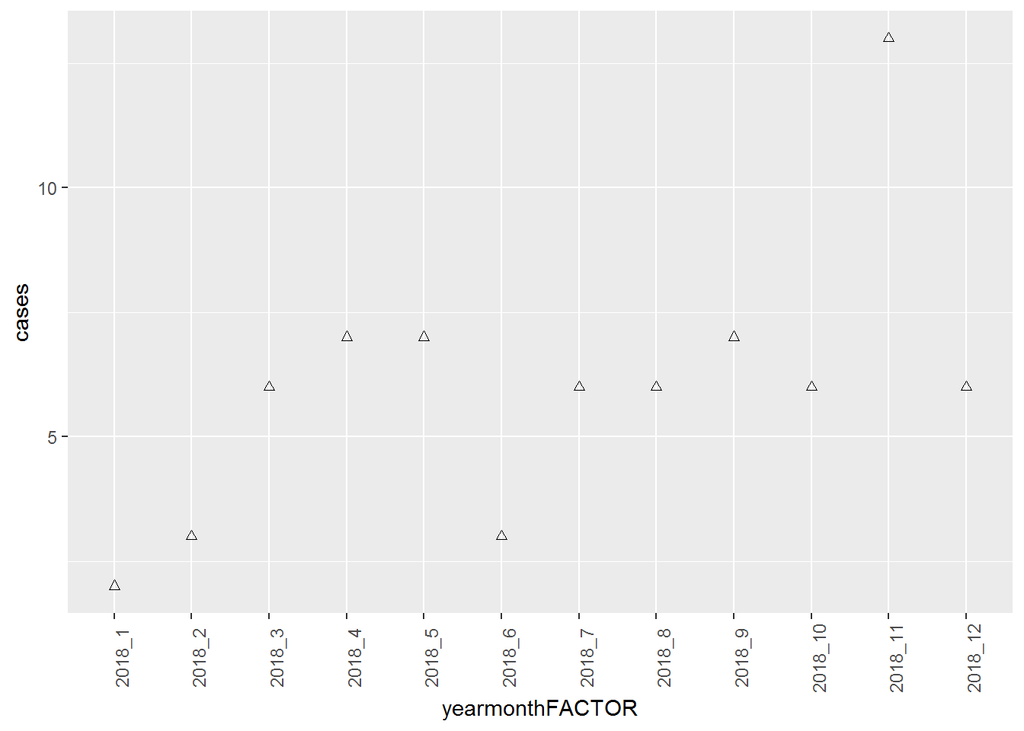

```r
ggplot(AFP_ATTOCK2018, aes(x=yearmonthFACTOR, y=cases, group=1)) + geom_point(shape = 2) +
  theme(axis.text.x=element_text(angle=90))
```

There are lots of themes to choose from. The most common have their own function e.g. `theme_bw()`.

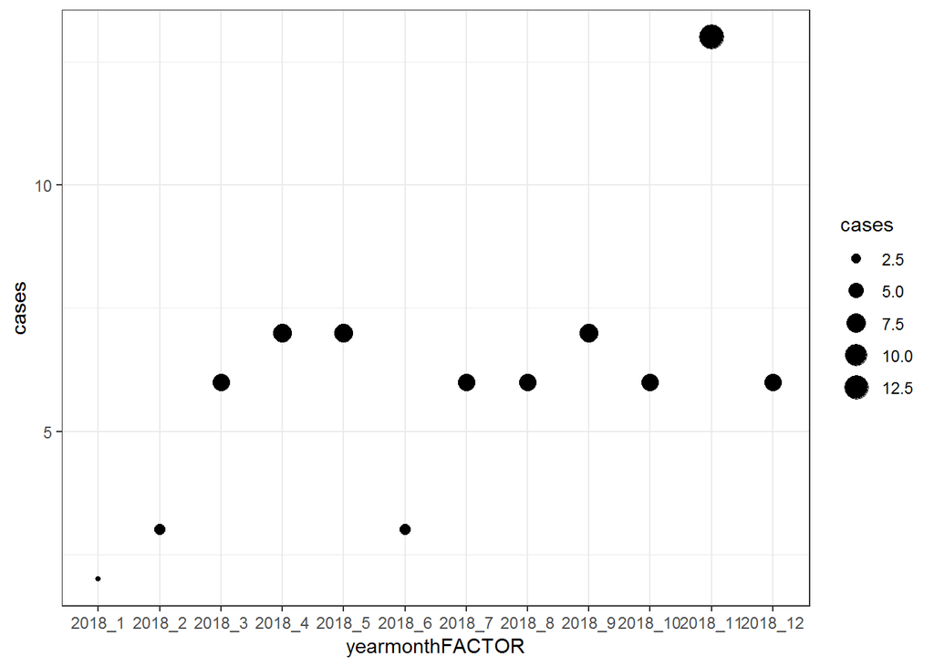

```r
ggplot(AFP_ATTOCK2018, aes(x=yearmonthFACTOR, y=cases, group=1)) +
  geom_point(aes(size = cases)) +
  theme_bw()
```

### Saving plots

Use the name of the plot you’ve assigned to save it.

```r
ggsave("my_plot.png", my_plot)
```